# R4DS_2E_layers

Martin

2026-01-19

## Layers - Aesthetic mappings

1. Create a scatterplot of hwy vs. displ where the points are pink filled in triangles.

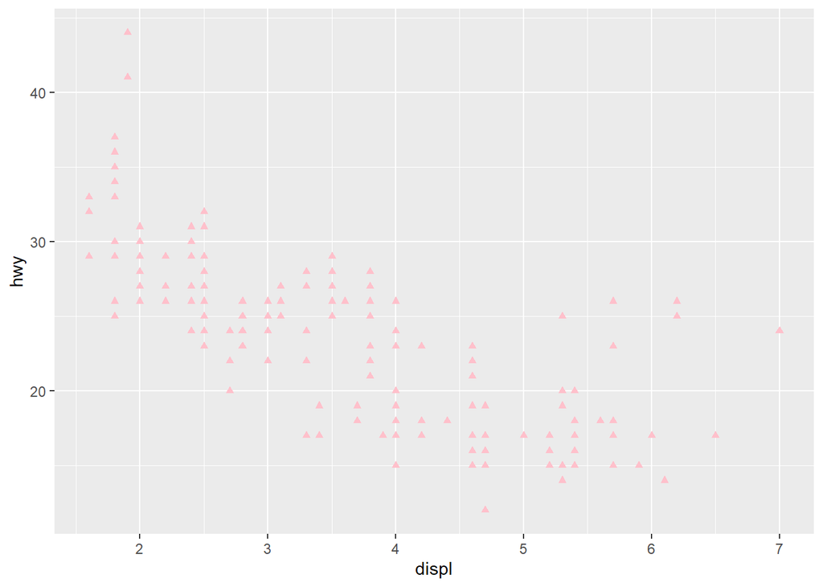

```r
ggplot(mpg, aes(x = displ, y = hwy)) +
  geom_point(colour = "pink", shape = 17)
```

2. Why did the following code not result in a plot with blue points?

```r
##ggplot(mpg) +
##  geom_point(aes(x = displ, y = hwy, color = "blue"))
# When color is set within an `aes()`, it is attempting a variable mapping to determine the appearence. So in the above example, `color = "blue"` is mapping the color of each variable based off the "variable", "blue". (Similar to how color = class works. Of course "blue" is not really a variable. It is a single value. Class has a bunch of different values in which the color aesthetic can map to)
```

3. What does the stroke aesthetic do? What shapes does it work with? (Hint: use ?geom_point)

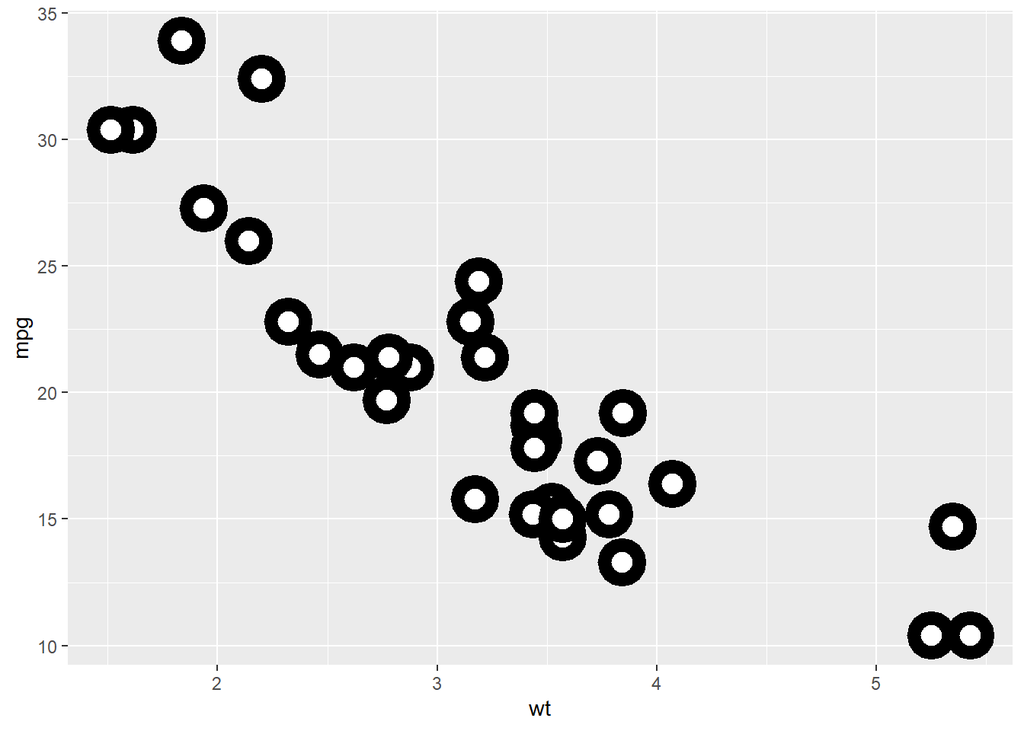

```r
# Looking at an example from the documentation:

# For shapes that have a border (like 21), you can colour the inside and
# outside separately. Use the stroke aesthetic to modify the width of the
# border
ggplot(mtcars, aes(wt, mpg)) +
  geom_point(shape = 21, colour = "black", fill = "white", size = 5, stroke = 5)
```

4. What happens if you map an aesthetic to something other than a variable name, like aes(color = displ < 5)? Note, you’ll also need to specify x and y.

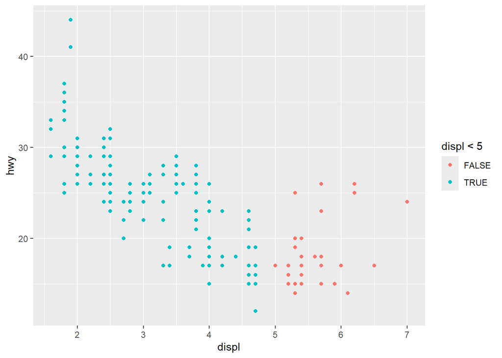

```r
ggplot(mpg, aes(x = displ, y = hwy, color = displ < 5)) +
  geom_point()
```

```r
# The following inequality `displ < 5` is either TRUE or FALSE. Thus this is a dichotomous mapping.
```

## Layers - Geometric objects

1. What geom would you use to draw a line chart? A boxplot? A histogram? An area chart?

```r
# geom_line() can be used to make a line graph with variables that make sense (time on x axis, some numeric quantity of y axis). Or we can use geom_smooth to create a "line chart" that is the line of best fit through all data points
##ggplot(mpg, aes(hwy, displ)) +
##  geom_smooth(se = FALSE)

##ggplot(mpg, aes(hwy, class)) +
##  geom_boxplot()

##ggplot(mpg, aes(hwy)) +
##  geom_histogram()

##ggplot(mpg, aes(x = hwy)) +
## geom_density()
```

2. Earlier in this chapter we used show.legend without explaining it:

What does show.legend = FALSE do here? What happens if you remove it? Why do you think we used it earlier?

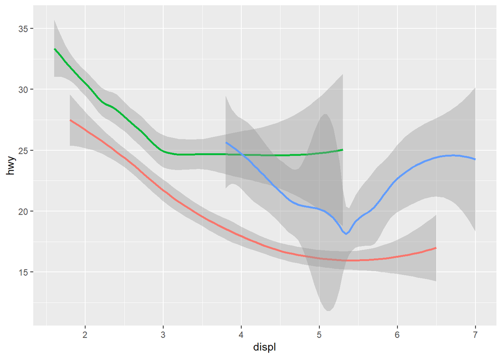

```r
ggplot(mpg, aes(x = displ, y = hwy)) +
  geom_smooth(aes(color = drv), show.legend = FALSE)
```

```r
# It won't show the legend describing which color maps to which drv value from our data. If we remove it, the legend will show (as show.legend is TRUE by default). It was removed earlier likely for space reasons (We can see our graph abit better now). Most of the time, removal of a legend is due to the fact that each line is obvious and we don't need to explicity have a legend to make sense of the plot.
```

3. What does the se argument to geom_smooth() do?

```r
# By default se = TRUE, which means a 95% confidence interval will be added around our line of best fits.
```

4. Recreate the R code necessary to generate the following graphs. Note that wherever a categorical variable is used in the plot, it’s drv.

[figure not shown]

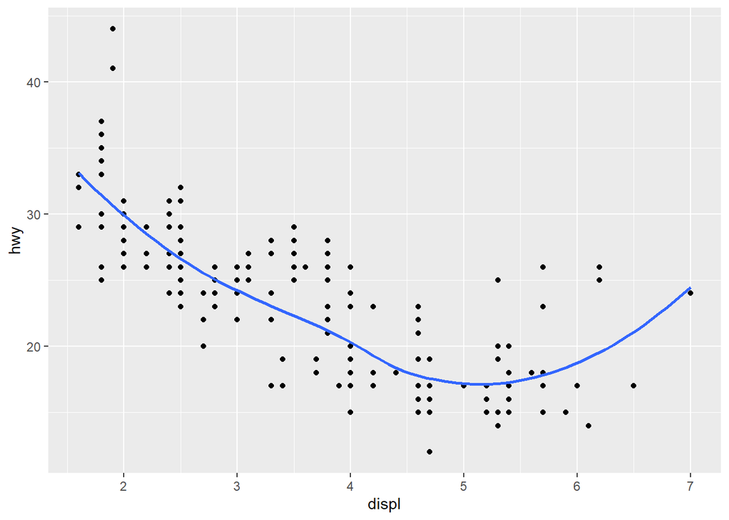

[figure not shown]

```r
ggplot(mpg, aes(displ, hwy)) +
  geom_point() +
  geom_smooth(se = FALSE)
```

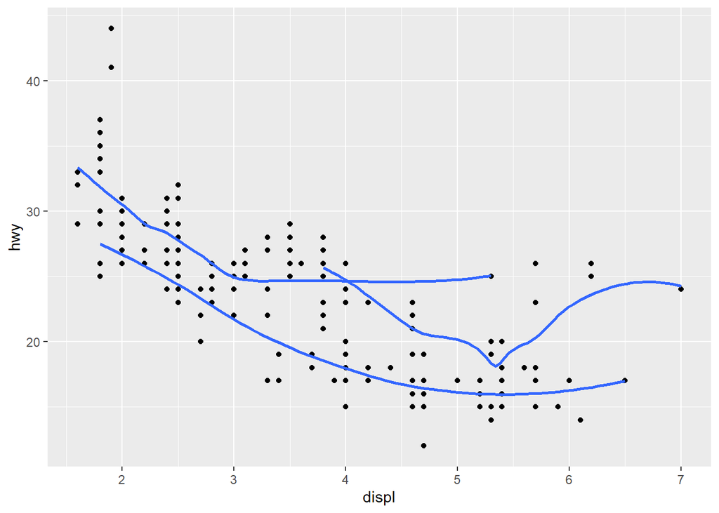

[figure not shown]

```r
ggplot(mpg, aes(displ, hwy)) +
  geom_point() +
  geom_smooth(aes(group = drv), se = FALSE)
```

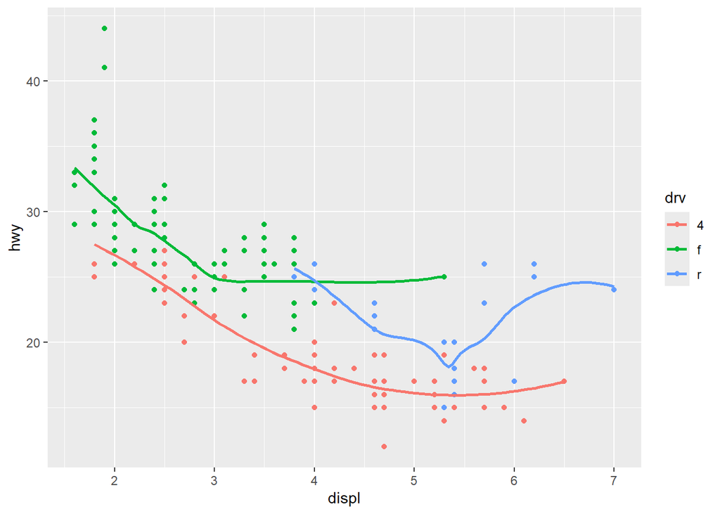

[figure not shown]

```r
ggplot(mpg, aes(displ, hwy, colour = drv)) +
  geom_point() +
  geom_smooth(se = FALSE)
```

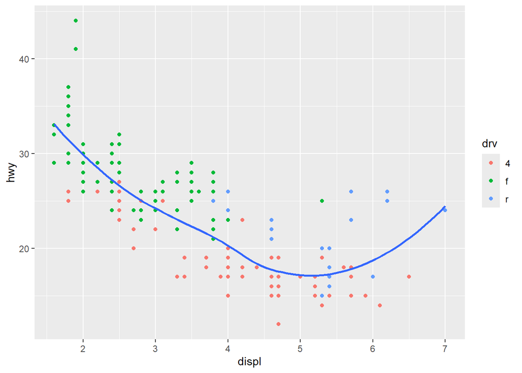

[figure not shown]

```r
ggplot(mpg, aes(displ, hwy)) +
  geom_point(aes(colour = drv)) +
  geom_smooth(se = FALSE)
```

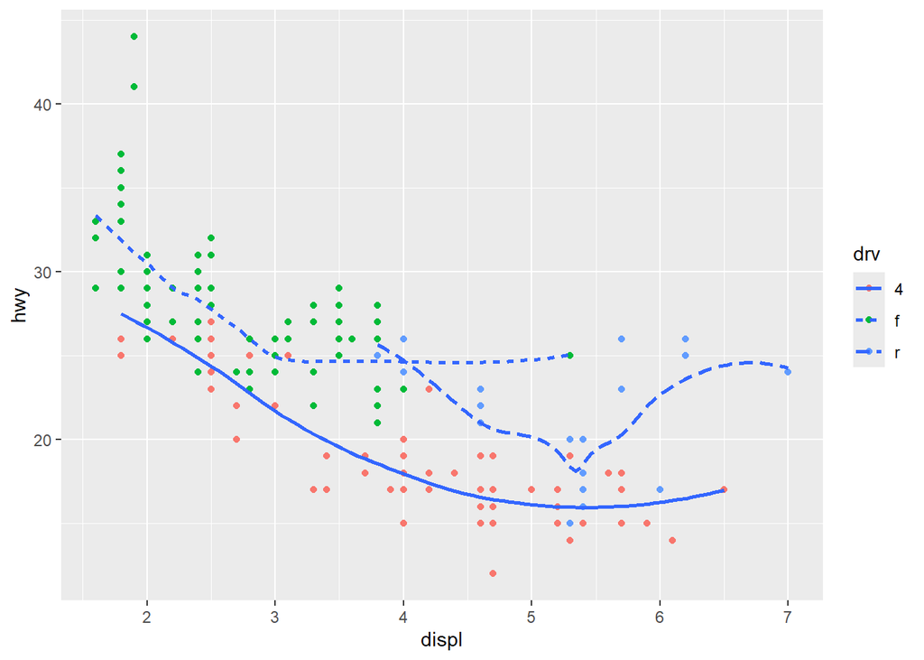

[figure not shown]

[figure not shown]

```r
ggplot(mpg, aes(displ, hwy)) +
  geom_point(aes(colour = drv)) +
  geom_smooth(aes(linetype = drv), se = FALSE)
```

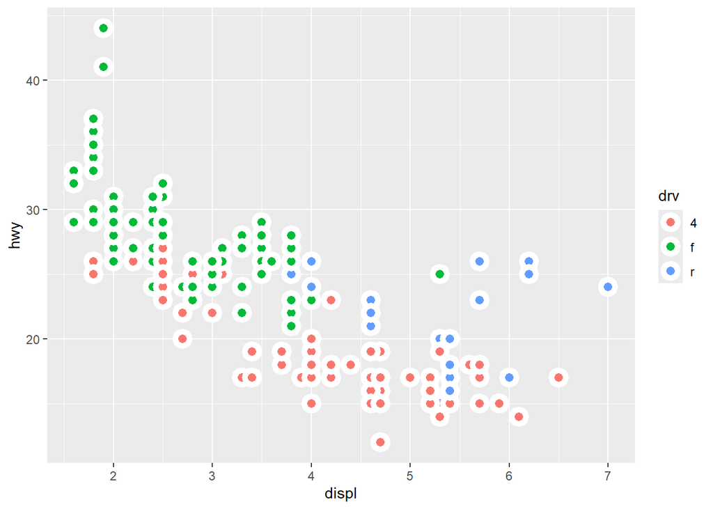

```r
ggplot(mpg, aes(displ, hwy, fill = drv)) +
  geom_point(shape = 21, size = 3, colour = "white", stroke = 3)
```

```r
# Shapes 21-24 have a border of colour and are filled with fill.
```

## Layers - Facets

1. What happens if you facet on a continuous variable?

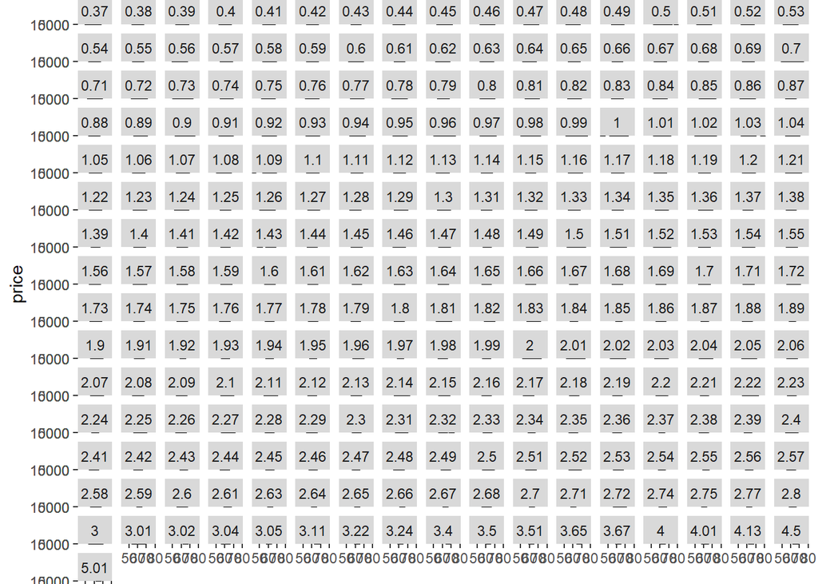

```r
ggplot(diamonds, aes(x = depth, y = price)) +
  geom_point() +
  facet_wrap(~carat)
```

```r
# It appears facet_wrap doesn't care if you use a continuous variable and forcefully wraps it anyway
```

2. What do the empty cells in the plot above with facet_grid(drv ~ cyl) mean? Run the following code. How do they relate to the resulting plot?

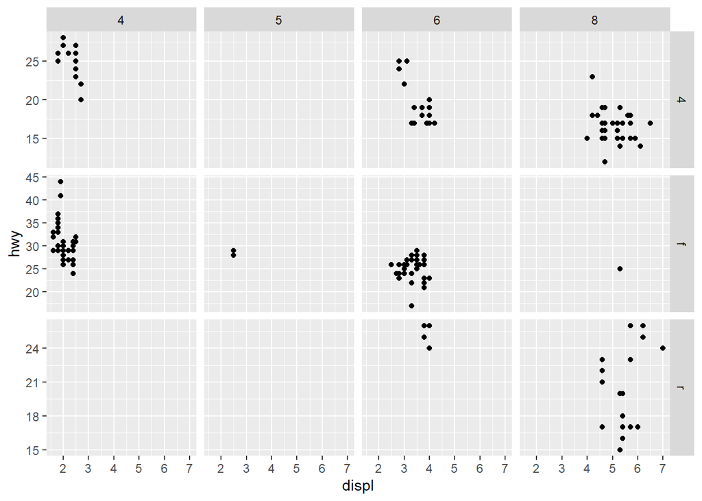

```r
# The above code mentioned is as follows:
ggplot(mpg, aes(x = displ, y = hwy)) +
  geom_point() +
  facet_grid(drv ~ cyl, scales = "free_y")
```

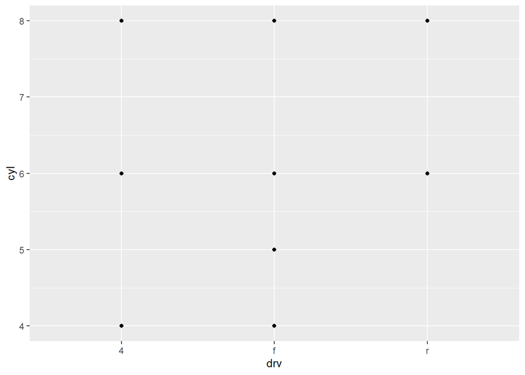

```r
# The empty celss tells us there are no data points for certain drv and cyl combinations. For example, in the dataset there are no 5 cylinder 4 wheel drive vehicles.

# Related plot:
ggplot(mpg) +
  geom_point(aes(x = drv, y = cyl))
```

```r
# We see a similar result here. No points for 5 cylinder 4 wheel drive, etc. facet wrap makes this result, arguably easier to see.
```

3. What plots does the following code make? What does . do?

```r
##ggplot(mpg) +
##  geom_point(aes(x = displ, y = hwy)) +
##  facet_grid(drv ~ .)

##ggplot(mpg) +
##  geom_point(aes(x = displ, y = hwy)) +
##  facet_grid(. ~ cyl)

# The . in this context appears to be a placeholder for whether we want our faceted variable (such as drv and cylinder) to be faceted by rows or columns
```

4. Take the first faceted plot in this section:

ggplot(mpg) + geom_point(aes(x = displ, y = hwy)) + facet_wrap(~ class, nrow = 2)

What are the advantages to using faceting instead of the color aesthetic? What are the disadvantages? How might the balance change if you had a larger dataset?

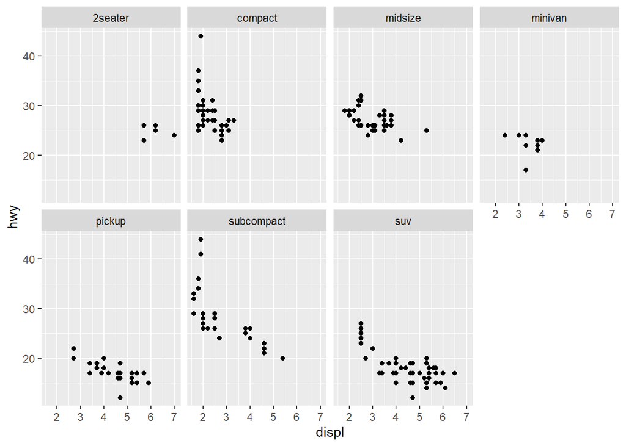

```r
ggplot(mpg) +
  geom_point(aes(x = displ, y = hwy)) +
  facet_wrap(~ class, nrow = 2)
```

```r
# Some advantages over coloring are that it is easier to separate between each class of vehicle. This advantage is even more obvious with a larger dataset where looking for differences between colours will be difficult (And the legend even bigger).
# Some disadvantages are since they aren't all on the same plot, differences between each class of vehicles, datawise, is harder to distinguish. Adding to this point, as each subplot is forced to be more compact, it is harder to see any relationships in the data. This disadvantage is amplied with larger datasets.
```

5. Read ?facet_wrap. What does nrow do? What does ncol do? What other options control the layout of the individual panels? Why doesn’t facet_grid() have nrow and ncol arguments?

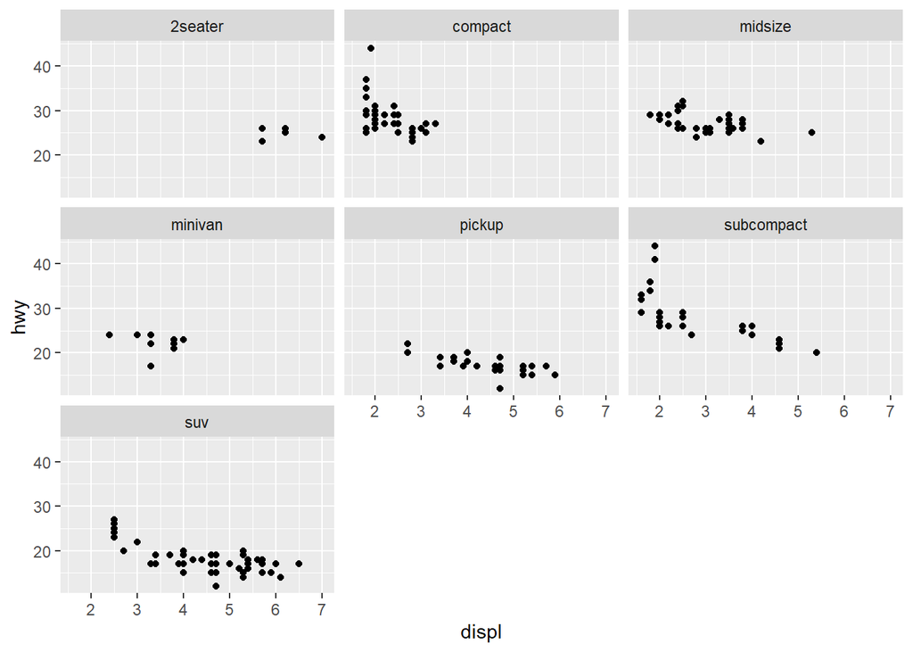

```r
# nrow and ncol are self-explanatory. Other arguments are things like `scales` which are related to the x & y axis. The `dir` argument defines how each subplot is added to the overall plot. For example "h" will add subplots horizontally (Left to right), while "v" adds them vertically (Top to bottom). This is easier to see with an example below:

ggplot(mpg) +
  geom_point(aes(x = displ, y = hwy)) +
  facet_wrap(~ class, dir = "h")
```

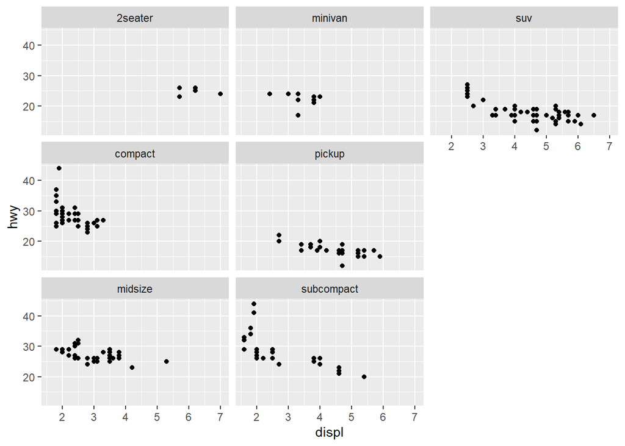

```r
ggplot(mpg) +
  geom_point(aes(x = displ, y = hwy)) +
  facet_wrap(~ class, dir = "v")
```

```r
# `facet_grid()` doesn't have nrow and ncol arguments since the two variables we choose within facet_grid will define the number of rows and number of columns. For example if we have a row variable with two possible values, and a column variable with three possible values, it will produce an overall plot with 6 subplots (2 x 3 = 6), with 2 rows and 3 columns. It cannot take imposed nrow and ncol arguments as this breaks the pairings between the x axis and y axis.
```

6. Which of the following plots makes it easier to compare engine size (displ) across cars with different drive trains? What does this say about when to place a faceting variable across rows or columns?

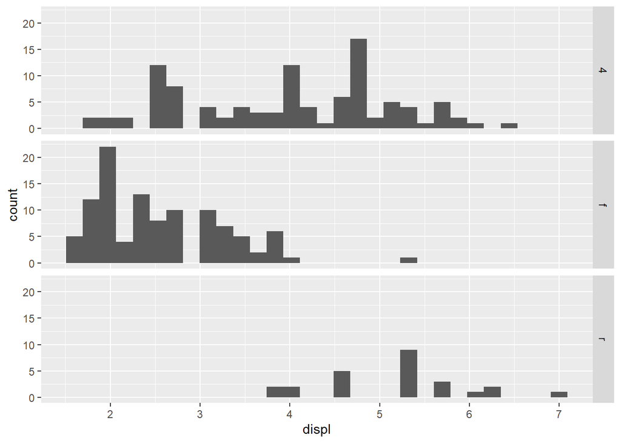

```r
ggplot(mpg, aes(x = displ)) +
  geom_histogram() +
  facet_grid(drv ~ .)
```

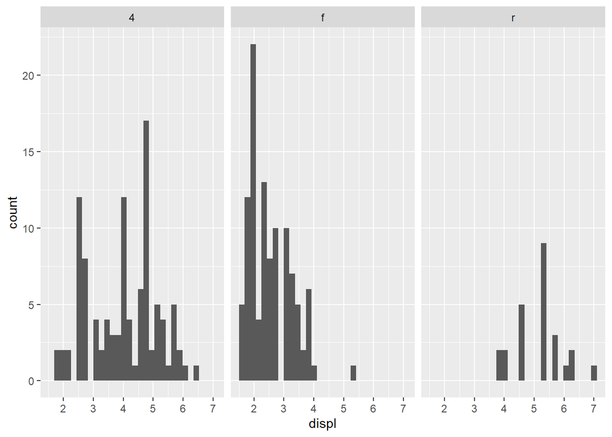

```r
ggplot(mpg, aes(x = displ)) +
  geom_histogram() +
  facet_grid(. ~ drv)
```

```r
# I would argue the first, since engine size, the primary focus of our plot, is easier to compare between different drive trains due to them all using the same x axis, unlike the second plot which uses the same y axis but not the same x axis. The width of each bin is easier to see as well.
# Care should be taken to consider whether the most important variable we want to compare between facets, (in this case its displ) should be using only a singular axis (preferred) rather than multiple of the same axes.
```

7. Recreate the following plot using facet_wrap() instead of facet_grid(). How do the positions of the facet labels change?

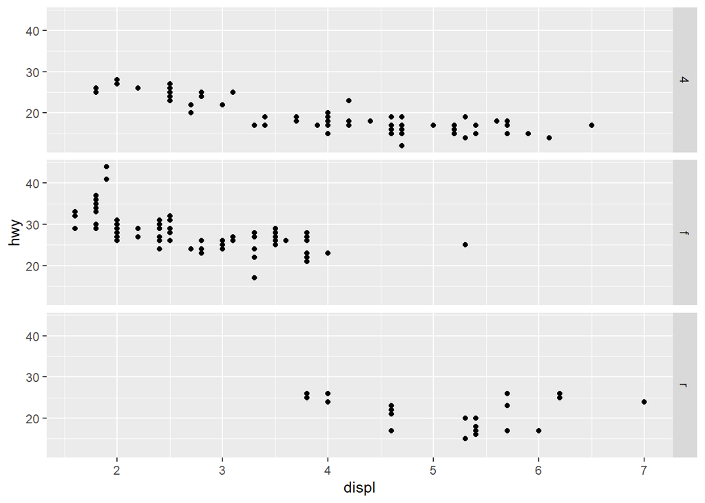

```r
ggplot(mpg) +
  geom_point(aes(x = displ, y = hwy)) +
  facet_grid(drv ~ .)
```

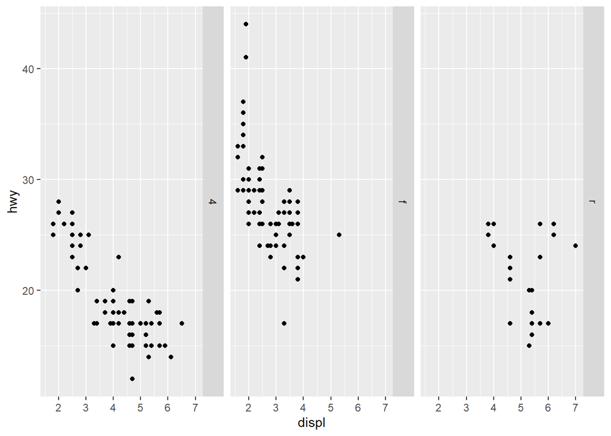

```r
ggplot(mpg) +
  geom_point(aes(x = displ, y = hwy)) +
  facet_wrap(~drv, dir = "v", strip.position = "right")
```

## Layers - Statistical Transformations

1. What is the default geom associated with stat_summary()? How could you rewrite the previous plot to use that geom function instead of the stat function?

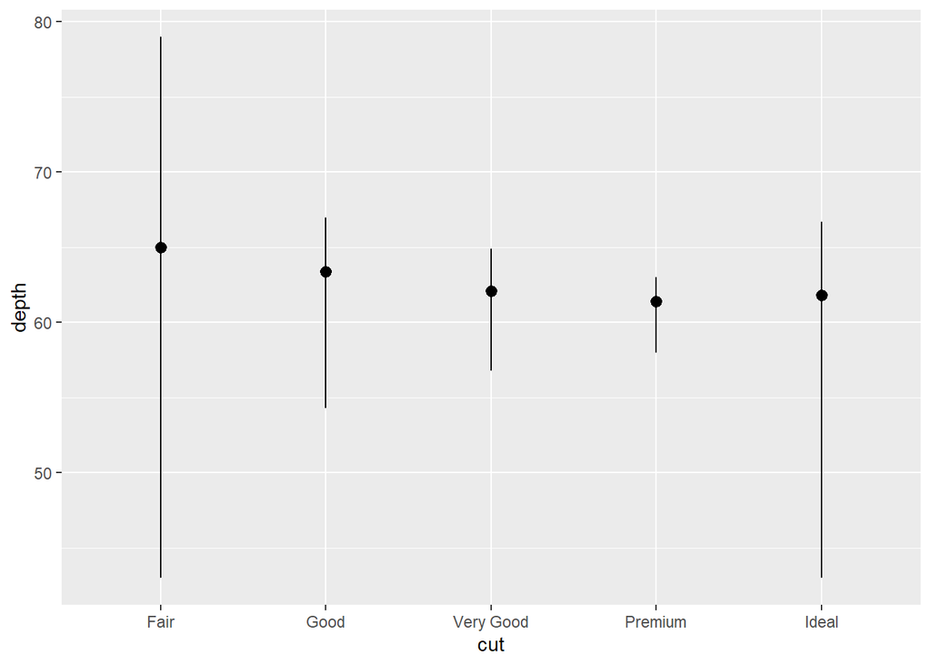

```r
# The default geom is geom_pointrange. (It is called "pointrange" only in the documentation since its stripped of the geom prefix)

ggplot(diamonds) +
  stat_summary(
    aes(x = cut, y = depth),
    fun.min = min,
    fun.max = max,
    fun = median
  )
```

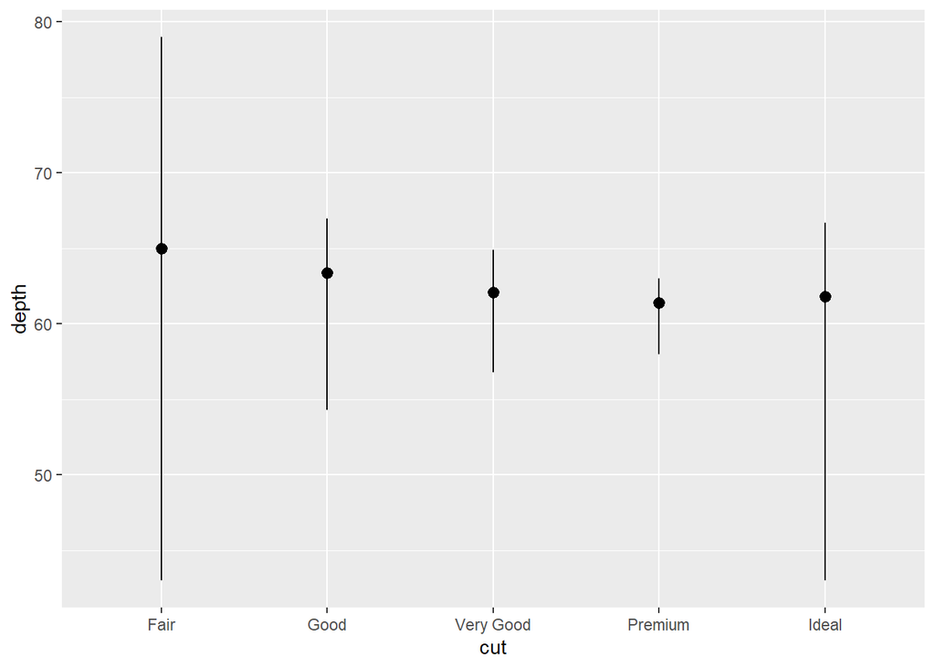

```r
ggplot(diamonds) +
  geom_pointrange(
    aes(x = cut, y = depth),
    stat = "summary",
    fun.min = min,
    fun.max = max,
    fun = median
  )
```

2. What does geom_col() do? How is it different from geom_bar()?

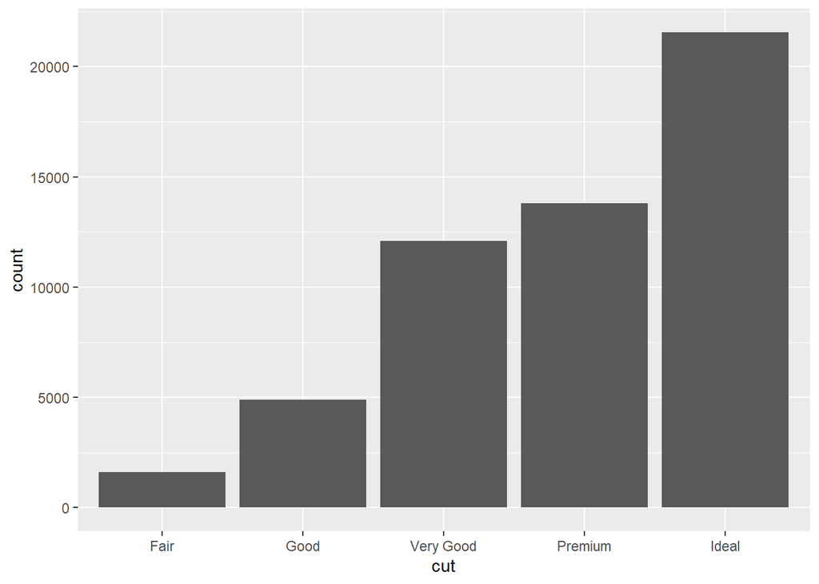

```r
# geom_bar() makes the height of the bar proportional to the number of cases in each group. If you want the heights of the bars to represent values in the data, use geom_col() instead. geom_bar() uses stat_count() by default: it counts the number of cases at each x position. geom_col() uses stat_identity(): it leaves the data as is. Here are some examples:

ggplot(diamonds, aes(x = cut)) +
  geom_bar()
```

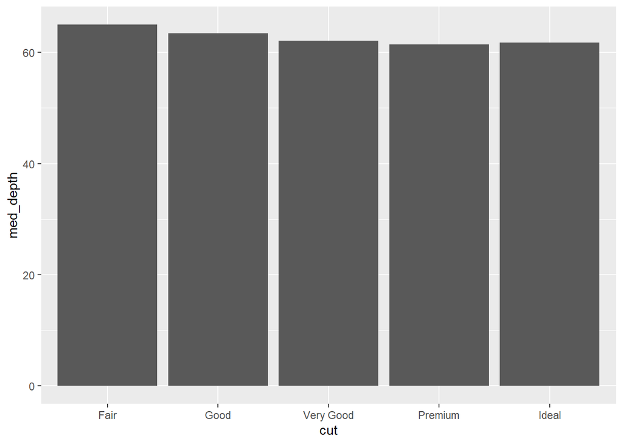

```r
diamonds_plus <- diamonds |>
  mutate(
    med_depth = median(depth, na.rm = TRUE),
    .by = cut
  ) |>
  summarize(
    n = n(),
    .by = c(cut, med_depth)
  )

ggplot(diamonds_plus, aes(cut, med_depth)) +
geom_col()
```

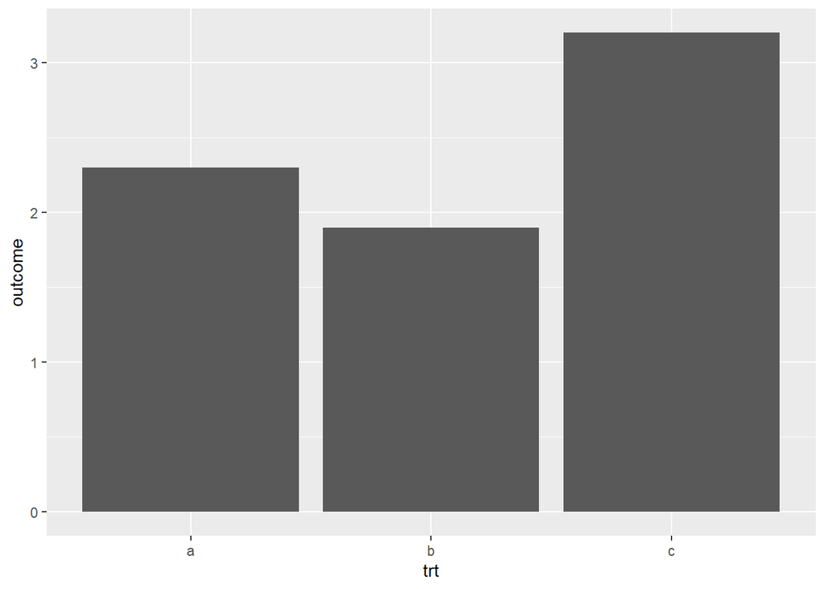

```r
df <- data.frame(trt = c("a", "b", "c"), outcome = c(2.3, 1.9, 3.2))
ggplot(df, aes(trt, outcome)) +
  geom_col()
```

3. Most geoms and stats come in pairs that are almost always used in concert. Make a list of all the pairs. What do they have in common? (Hint: Read through the documentation.)

```r
# `geom_bar`,  with `stat = "count"`. `geom_hist`, `geom_freqpoly` with `stat = "bin"` etc. The geoms uses a relevant stat based off what data is generally being supplied to each geom. So for example we usually use geom_bar if we have discrete data which is best fit for stat = "count". Similar argument for geom_hist & geom_freqpoly since they are supplied continous data they use stat = "bin" instead.
```

4. What variables does stat_smooth() compute? What arguments control its behavior?

```r
# stat_smooth() provides the following variables, some of which depend on the orientation:
# after_stat(y) or after_stat(x)
# Predicted value.
#
# after_stat(ymin) or after_stat(xmin)
# Lower pointwise confidence interval around the mean.
#
# after_stat(ymax) or after_stat(xmax)
# Upper pointwise confidence interval around the mean.
#
# after_stat(se)
# Standard error.


# Some of the arguments that control its behaviour are the following:
# method = NULL,
# formula = NULL,
# se = TRUE,
# n = 80,
# span = 0.75,
# fullrange = FALSE,
# level = 0.95,
# method.args = list(),
# na.rm = FALSE,
# orientation = NA,
# show.legend = NA,
# inherit.aes = TRUE
```

5. In our proportion bar chart, we need to set group = 1. Why? In other words, what is the problem with these two graphs?

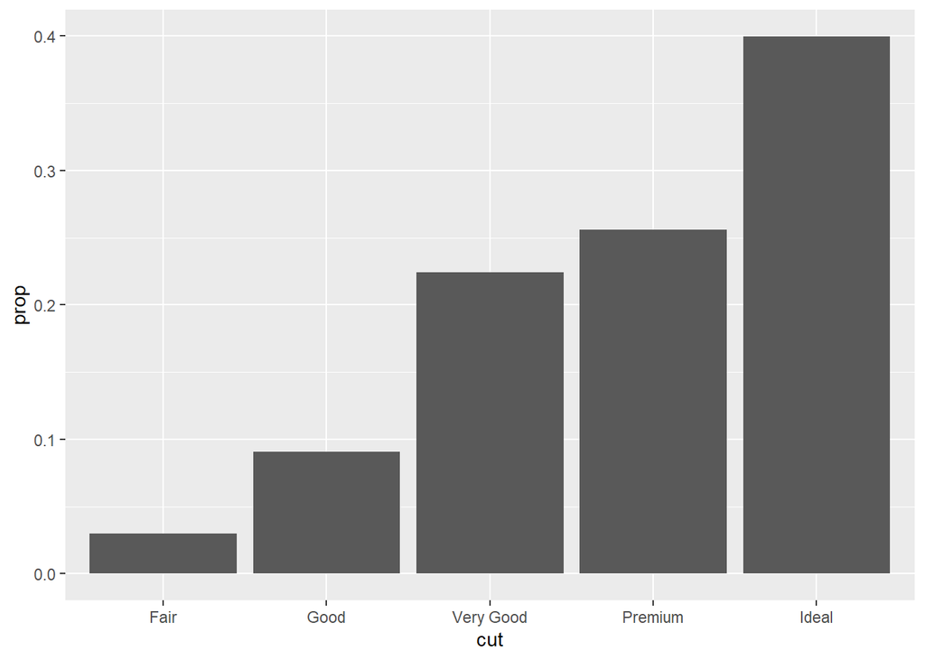

```r
# after_stat is an expression using the variables calculated by the stat. So in this case since we are using `geom_bar` it will calculate respective proportions based off `stat_count`.
ggplot(diamonds, aes(x = cut, y = after_stat(prop), group = 1)) +
  geom_bar()
```

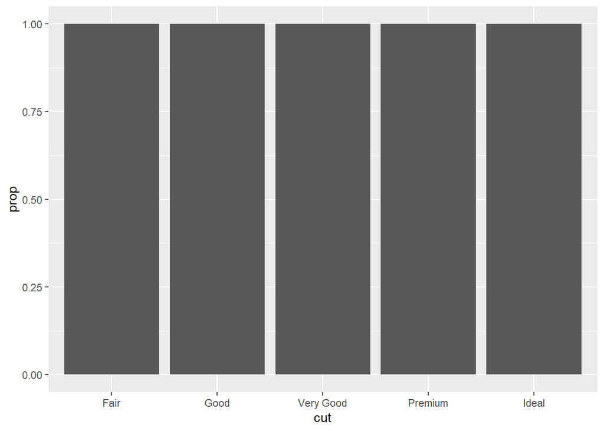

```r
# The bars are not grouped together because the group aesthetic is not set. As a result, each bar is treated as an individual entity, and the heights of the bars represent the proportion of each category within its own group. Since there is no grouping, the proportions are calculated independently for each bar, which leads to incorrect proportions being displayed, which is whatever the highest prop value is as its only comparing proportion values with itself. (Value of 1 for first plot, 7 for second plot)
ggplot(diamonds, aes(x = cut, y = after_stat(prop))) +
  geom_bar()
```

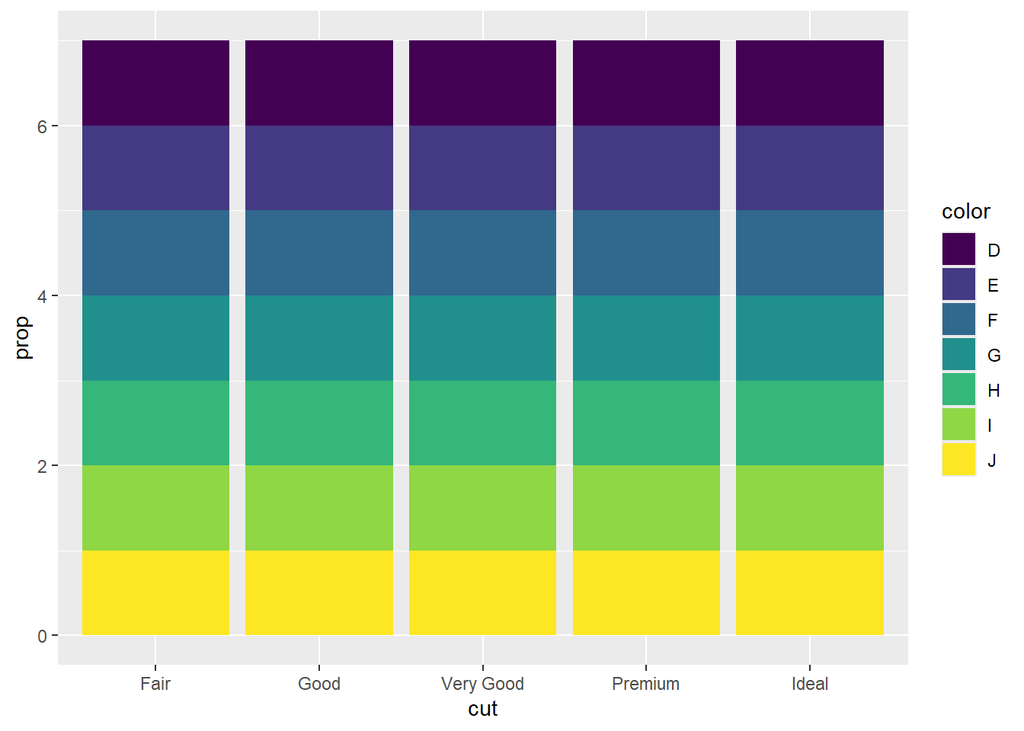

```r
ggplot(diamonds, aes(x = cut, fill = color, y = after_stat(prop))) +
  geom_bar()
```